# Problem Set Lesson 3

Ransford Hyman Jr.

November 23, 2015

```r
library(ggplot2)
data(diamonds)
summary(diamonds)
```

```
##      carat               cut        color        clarity
##  Min.   :0.2000   Fair     : 1610   D: 6775   SI1    :13065
##  1st Qu.:0.4000   Good     : 4906   E: 9797   VS2    :12258
##  Median :0.7000   Very Good:12082   F: 9542   SI2    : 9194
##  Mean   :0.7979   Premium  :13791   G:11292   VS1    : 8171
##  3rd Qu.:1.0400   Ideal    :21551   H: 8304   VVS2   : 5066
##  Max.   :5.0100                     I: 5422   VVS1   : 3655
##                                     J: 2808   (Other): 2531
##      depth           table           price             x
##  Min.   :43.00   Min.   :43.00   Min.   :  326   Min.   : 0.000
##  1st Qu.:61.00   1st Qu.:56.00   1st Qu.:  950   1st Qu.: 4.710
##  Median :61.80   Median :57.00   Median : 2401   Median : 5.700
##  Mean   :61.75   Mean   :57.46   Mean   : 3933   Mean   : 5.731
##  3rd Qu.:62.50   3rd Qu.:59.00   3rd Qu.: 5324   3rd Qu.: 6.540
##  Max.   :79.00   Max.   :95.00   Max.   :18823   Max.   :10.740
##
##        y                z
##  Min.   : 0.000   Min.   : 0.000
##  1st Qu.: 4.720   1st Qu.: 2.910
##  Median : 5.710   Median : 3.530
##  Mean   : 5.735   Mean   : 3.539
##  3rd Qu.: 6.540   3rd Qu.: 4.040
##  Max.   :58.900   Max.   :31.800
##
```

```r
#?diamonds
```

Question #2: Below we generate a histogram for the prices of the diamonds in the diamond set. The price distribution is a long-tailed distribution. The median value is $2401 and the mean value is $3933 for this distribution.

```
## stat_bin: binwidth defaulted to range/30. Use 'binwidth = x' to adjust this.
```

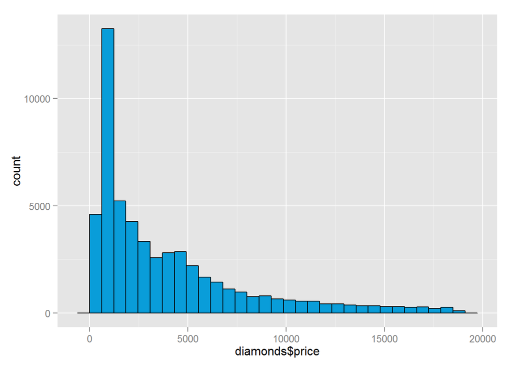

```r
qplot(x=diamonds$price, df = diamonds,
      color = I('black'), fill = I('#099DD9'))
```

```r
summary(diamonds$price)
```

```
##    Min. 1st Qu.  Median    Mean 3rd Qu.    Max.
##     326     950    2401    3933    5324   18820
```

Question #3: Here we give some analysis about the number of diamonds that fit within a specific range

```r
dim(subset(diamonds, price < 500))
```

```
## [1] 1729   10
```

```r
dim(subset(diamonds, price < 250))
```

```
## [1]  0 10
```

```r
dim(subset(diamonds, price >= 15000))
```

```
## [1] 1656   10
```

Question #4: Exploring the spike in the histgram. Here I will zoom in on the spike to see if there is anything interesting there.

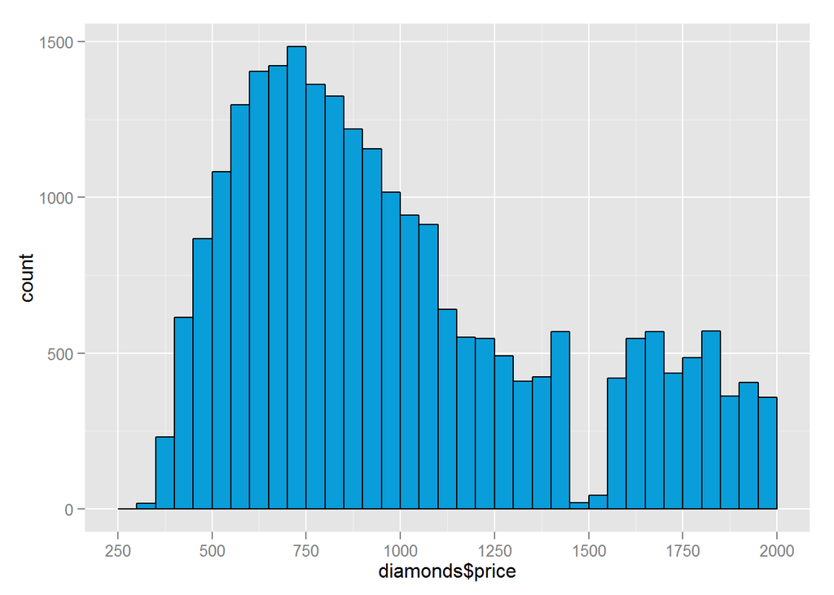

```r
qplot(x=diamonds$price, df = diamonds, binwidth=50,
      color = I('black'), fill = I('#099DD9')) +
  scale_x_continuous(limits = c(250,2000), breaks= seq(250,2000,250))
```

Question #5: Generate graphs based on cut

```
## stat_bin: binwidth defaulted to range/30. Use 'binwidth = x' to adjust this.
## stat_bin: binwidth defaulted to range/30. Use 'binwidth = x' to adjust this.
## stat_bin: binwidth defaulted to range/30. Use 'binwidth = x' to adjust this.
## stat_bin: binwidth defaulted to range/30. Use 'binwidth = x' to adjust this.
## stat_bin: binwidth defaulted to range/30. Use 'binwidth = x' to adjust this.
```

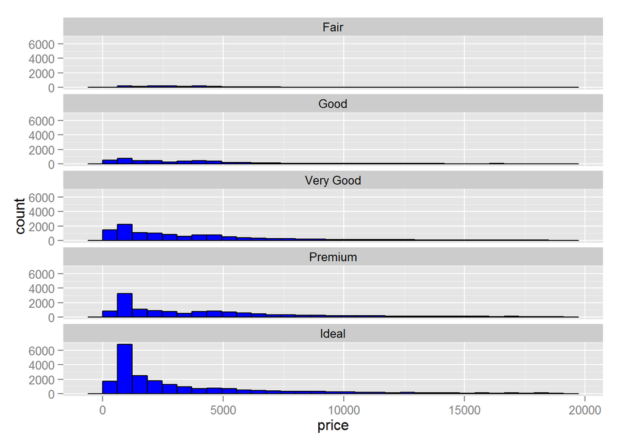

```r
ggplot(diamonds,aes(x=price), binwidth=50) +
  geom_histogram(color = 'black',fill = 'blue') +
  facet_wrap(~cut,ncol = 1)
```

Question #6: Zooming in on the facet wrap plot for highest priced diamond based on cut

```
## stat_bin: binwidth defaulted to range/30. Use 'binwidth = x' to adjust this.
## stat_bin: binwidth defaulted to range/30. Use 'binwidth = x' to adjust this.
## stat_bin: binwidth defaulted to range/30. Use 'binwidth = x' to adjust this.
## stat_bin: binwidth defaulted to range/30. Use 'binwidth = x' to adjust this.
## stat_bin: binwidth defaulted to range/30. Use 'binwidth = x' to adjust this.
```

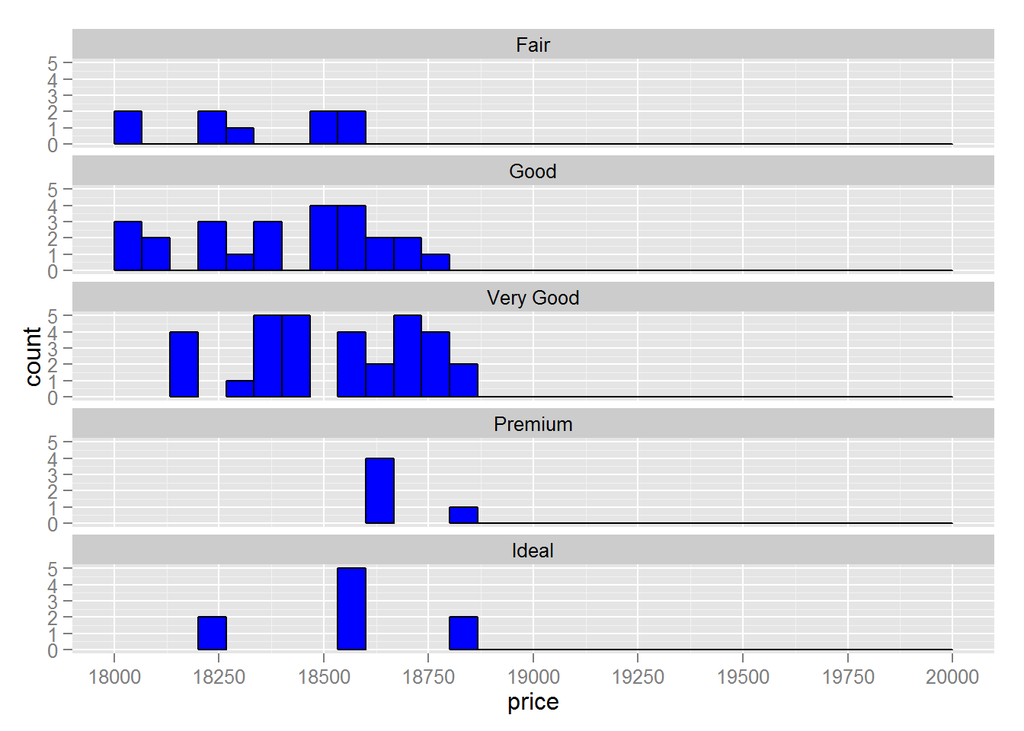

```r
ggplot(diamonds,aes(x=price), binwidth=50) +
  geom_histogram(color = 'black',fill = 'blue') +
  scale_x_continuous(limits=c(18000,20000),breaks = seq(18000,20000,250)) +
  scale_y_continuous(limits=c(0,5)) +
  facet_wrap(~cut,ncol = 1)
```

Question #6: Zooming in on the facet wrap plot for lowest priced diamond based on cut

```
## stat_bin: binwidth defaulted to range/30. Use 'binwidth = x' to adjust this.
## stat_bin: binwidth defaulted to range/30. Use 'binwidth = x' to adjust this.
## stat_bin: binwidth defaulted to range/30. Use 'binwidth = x' to adjust this.
## stat_bin: binwidth defaulted to range/30. Use 'binwidth = x' to adjust this.
## stat_bin: binwidth defaulted to range/30. Use 'binwidth = x' to adjust this.
```

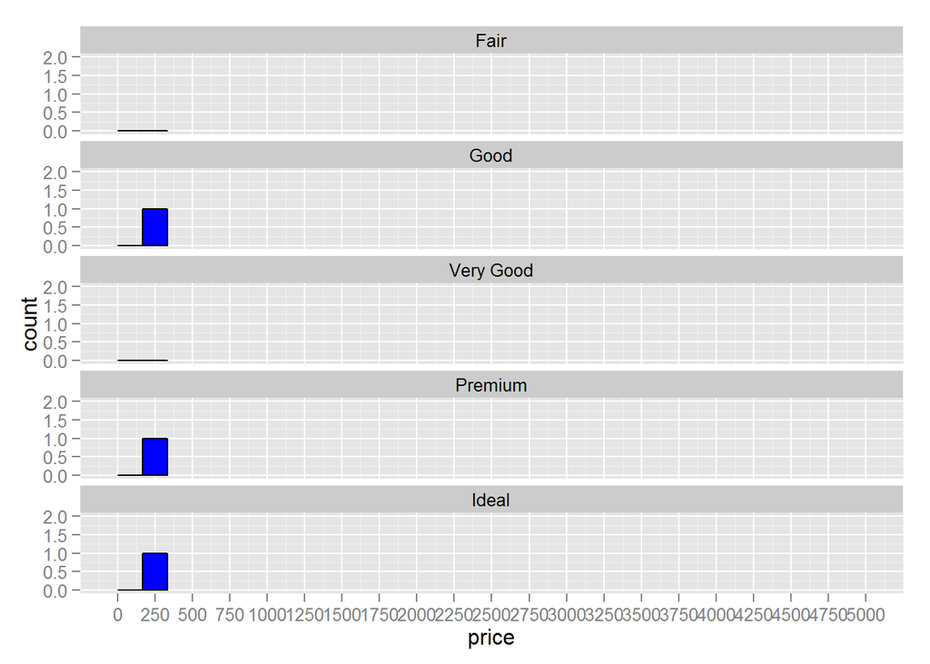

```r
ggplot(diamonds,aes(x=price), binwidth=10) +
  geom_histogram(color = 'black',fill = 'blue') +
  scale_x_continuous(limits=c(0,5000),breaks = seq(0,5000,250)) +
  scale_y_continuous(limits=c(0,2)) +
  facet_wrap(~cut,ncol = 1)
```

Question #6: Finding out summary info on diamonds by cut

```r
by(diamonds$price,diamonds$cut,summary)
```

```
## diamonds$cut: Fair
##    Min. 1st Qu.  Median    Mean 3rd Qu.    Max.
##     337    2050    3282    4359    5206   18570
## --------------------------------------------------------
## diamonds$cut: Good
##    Min. 1st Qu.  Median    Mean 3rd Qu.    Max.
##     327    1145    3050    3929    5028   18790
## --------------------------------------------------------
## diamonds$cut: Very Good
##    Min. 1st Qu.  Median    Mean 3rd Qu.    Max.
##     336     912    2648    3982    5373   18820
## --------------------------------------------------------
## diamonds$cut: Premium
##    Min. 1st Qu.  Median    Mean 3rd Qu.    Max.
##     326    1046    3185    4584    6296   18820
## --------------------------------------------------------
## diamonds$cut: Ideal
##    Min. 1st Qu.  Median    Mean 3rd Qu.    Max.
##     326     878    1810    3458    4678   18810
```

Question #7: Generate graphs based on cut with better y axis

```
## stat_bin: binwidth defaulted to range/30. Use 'binwidth = x' to adjust this.
## stat_bin: binwidth defaulted to range/30. Use 'binwidth = x' to adjust this.
## stat_bin: binwidth defaulted to range/30. Use 'binwidth = x' to adjust this.
## stat_bin: binwidth defaulted to range/30. Use 'binwidth = x' to adjust this.
## stat_bin: binwidth defaulted to range/30. Use 'binwidth = x' to adjust this.
```

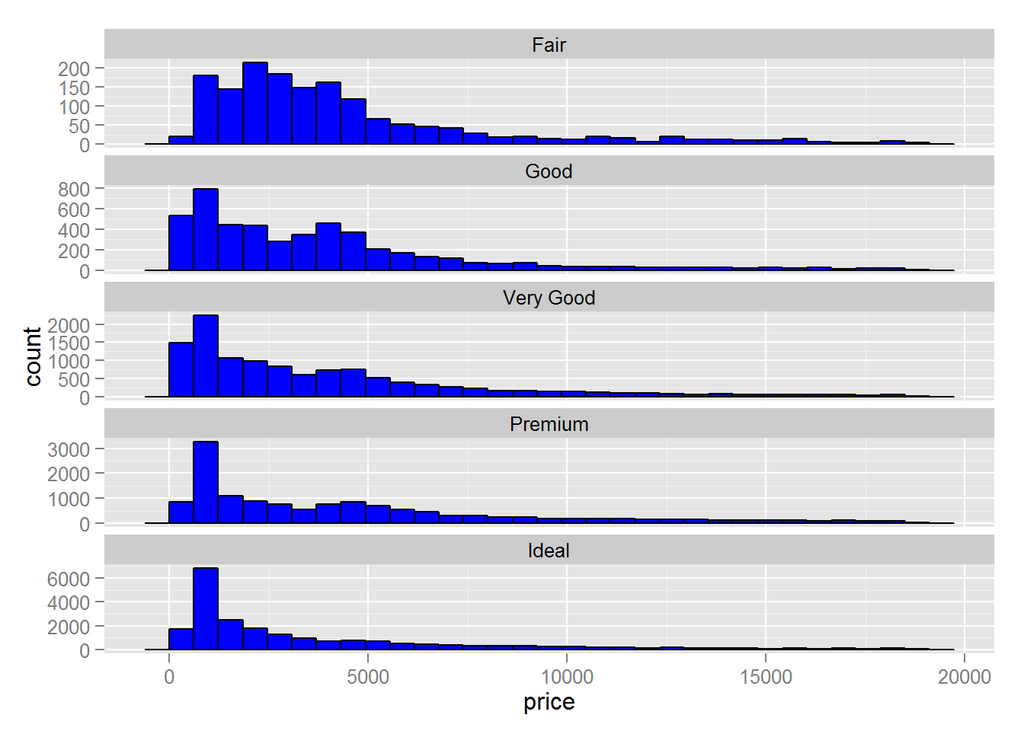

```r
ggplot(diamonds,aes(x=price), binwidth=50) +
  geom_histogram(color = 'black',fill = 'blue') +
  facet_wrap(~cut,ncol = 1,scales='free_y')
```

```r
#?facet_wrap
```

Question #8: Histogram of price per caret

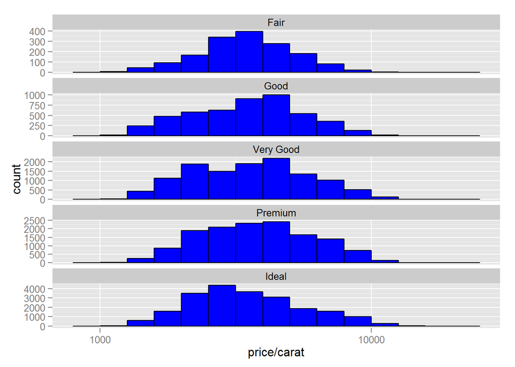

```r
ggplot(diamonds,aes(x=price/carat)) +
  geom_histogram(binwidth=0.1,color = 'black',fill = 'blue') +
  scale_x_log10() +
  facet_wrap(~cut,ncol = 1,scales='free_y')
```

```r
str(diamonds)
```

```
## 'data.frame':    53940 obs. of  10 variables:
##  $ carat  : num  0.23 0.21 0.23 0.29 0.31 0.24 0.24 0.26 0.22 0.23 ...
##  $ cut    : Ord.factor w/ 5 levels "Fair"<"Good"<..: 5 4 2 4 2 3 3 3 1 3 ...
##  $ color  : Ord.factor w/ 7 levels "D"<"E"<"F"<"G"<..: 2 2 2 6 7 7 6 5 2 5 ...
##  $ clarity: Ord.factor w/ 8 levels "I1"<"SI2"<"SI1"<..: 2 3 5 4 2 6 7 3 4 5 ...
##  $ depth  : num  61.5 59.8 56.9 62.4 63.3 62.8 62.3 61.9 65.1 59.4 ...
##  $ table  : num  55 61 65 58 58 57 57 55 61 61 ...
##  $ price  : int  326 326 327 334 335 336 336 337 337 338 ...
##  $ x      : num  3.95 3.89 4.05 4.2 4.34 3.94 3.95 4.07 3.87 4 ...
##  $ y      : num  3.98 3.84 4.07 4.23 4.35 3.96 3.98 4.11 3.78 4.05 ...
##  $ z      : num  2.43 2.31 2.31 2.63 2.75 2.48 2.47 2.53 2.49 2.39 ...
```

Question #9: Generation of Boxplot based on price by cut

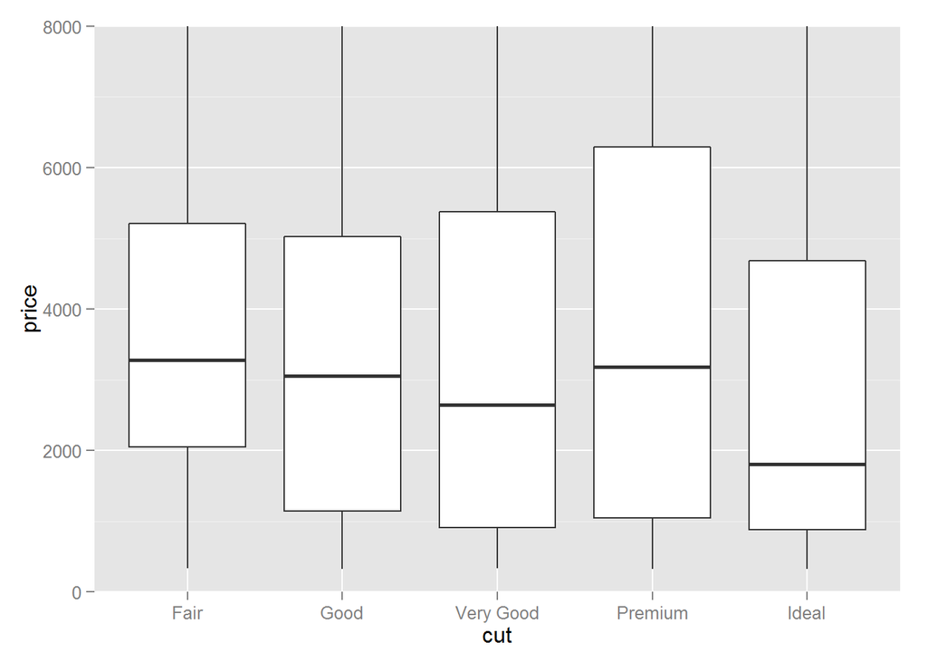

```r
ggplot(diamonds,aes(x=cut,y=price)) +
  geom_boxplot() +
 coord_cartesian(ylim = c(0,8000))
```

```r
#?diamonds
```

```r
by(diamonds$price,diamonds$color,summary)
```

```
## diamonds$color: D
##    Min. 1st Qu.  Median    Mean 3rd Qu.    Max.
##     357     911    1838    3170    4214   18690
## --------------------------------------------------------
## diamonds$color: E
##    Min. 1st Qu.  Median    Mean 3rd Qu.    Max.
##     326     882    1739    3077    4003   18730
## --------------------------------------------------------
## diamonds$color: F
##    Min. 1st Qu.  Median    Mean 3rd Qu.    Max.
##     342     982    2344    3725    4868   18790
## --------------------------------------------------------
## diamonds$color: G
##    Min. 1st Qu.  Median    Mean 3rd Qu.    Max.
##     354     931    2242    3999    6048   18820
## --------------------------------------------------------
## diamonds$color: H
##    Min. 1st Qu.  Median    Mean 3rd Qu.    Max.
##     337     984    3460    4487    5980   18800
## --------------------------------------------------------
## diamonds$color: I
##    Min. 1st Qu.  Median    Mean 3rd Qu.    Max.
##     334    1120    3730    5092    7202   18820
## --------------------------------------------------------
## diamonds$color: J
##    Min. 1st Qu.  Median    Mean 3rd Qu.    Max.
##     335    1860    4234    5324    7695   18710
```

```r
IQR(subset(diamonds, color=="D")$price)
```

```
## [1] 3302.5
```

```r
str(diamonds)
```

```
## 'data.frame':    53940 obs. of  10 variables:
##  $ carat  : num  0.23 0.21 0.23 0.29 0.31 0.24 0.24 0.26 0.22 0.23 ...
##  $ cut    : Ord.factor w/ 5 levels "Fair"<"Good"<..: 5 4 2 4 2 3 3 3 1 3 ...
##  $ color  : Ord.factor w/ 7 levels "D"<"E"<"F"<"G"<..: 2 2 2 6 7 7 6 5 2 5 ...
##  $ clarity: Ord.factor w/ 8 levels "I1"<"SI2"<"SI1"<..: 2 3 5 4 2 6 7 3 4 5 ...
##  $ depth  : num  61.5 59.8 56.9 62.4 63.3 62.8 62.3 61.9 65.1 59.4 ...
##  $ table  : num  55 61 65 58 58 57 57 55 61 61 ...
##  $ price  : int  326 326 327 334 335 336 336 337 337 338 ...
##  $ x      : num  3.95 3.89 4.05 4.2 4.34 3.94 3.95 4.07 3.87 4 ...
##  $ y      : num  3.98 3.84 4.07 4.23 4.35 3.96 3.98 4.11 3.78 4.05 ...
##  $ z      : num  2.43 2.31 2.31 2.63 2.75 2.48 2.47 2.53 2.49 2.39 ...
```

Question #10: boxplots with price/caret over various colors

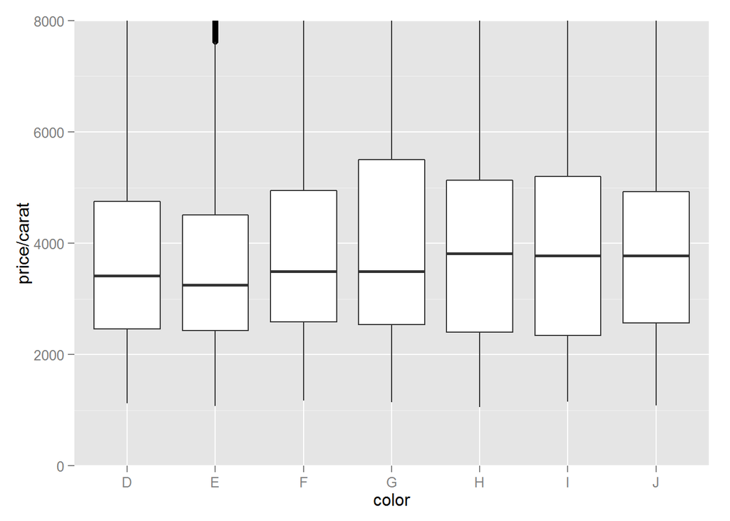

```r
ggplot(diamonds,aes(x=color,y=price/carat)) +
  geom_boxplot() +
  coord_cartesian(ylim = c(0,8000))
```

Question #11: Frequency polygon of the various carats

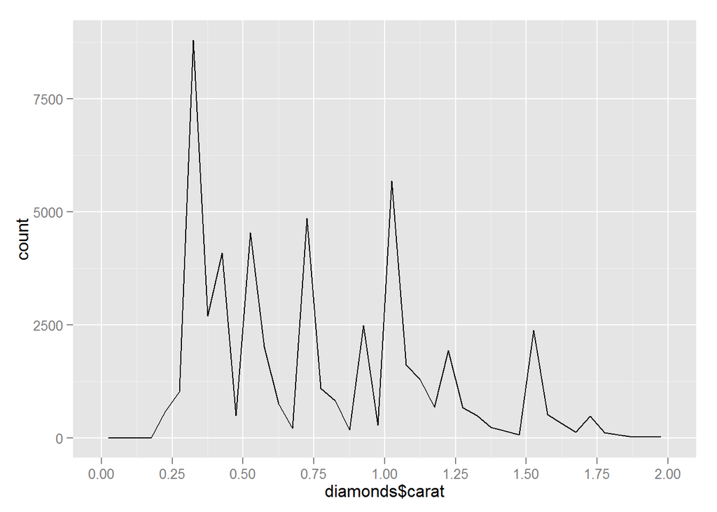

```r
qplot(diamonds$carat, df=diamonds,binwidth=0.05,
      geom = "freqpoly") +
  scale_x_continuous(limits=c(0,2),breaks=seq(0,2,0.25))
```

```r
summary(diamonds$carat)
```

```
##    Min. 1st Qu.  Median    Mean 3rd Qu.    Max.
##  0.2000  0.4000  0.7000  0.7979  1.0400  5.0100
```

```r
#install.packages("tidyr")
library(tidyr)
library(dplyr)
#devtools::install_github("rstudio/EDAWR")
#?gather
```

```r
#setwd("C:\\Users\\ransf\\OneDrive\\Documents\\GitHub\\Data-Analysis-With-R\\Lesson3")
gdp <- read.csv('indicator_gdp\ per\ employee.csv')
#Remove the last row since it empty
gdp <- gdp[1:128,]
#Checking whether there are any NA values
table(is.na(gdp$X1995))
```

```
##
## FALSE
##   128
```

```r
p0 <-ggplot(gdp, aes(x=X1990)) + xlab('GDP per employee in 1990 (in 1990 US dollars)') + ylab('Number of countries')
p0 <- p0 + geom_freqpoly(color='red', binwidth=1000)
p0 <-  p0 + scale_x_continuous(limits=c(0,62000),breaks=seq(0,62000,10000))
#p0

p1 <-ggplot(gdp, aes(x=X1995,color='blue')) + xlab('GDP per employee in 1995 (in 1990 US dollars)') + ylab('Number of countries')
p1 <-  p1 + geom_freqpoly(color='blue',binwidth=1000)
p1 <- p1 + scale_x_continuous(limits=c(0,62000),breaks=seq(0,62000,10000))
#p1
#Checking whether there are any NA values
table(is.na(gdp$X2005))
```

```
##
## FALSE  TRUE
##   127     1
```

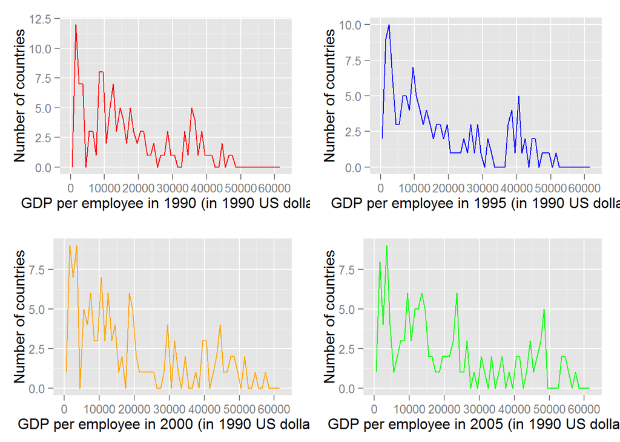

```r
p2 <- ggplot(gdp, aes(x=X2005)) + xlab('GDP per employee in 2005 (in 1990 US dollars)') + ylab('Number of countries')
p2 <- p2 + geom_freqpoly(color='green',binwidth=1000)
p2 <- p2 + scale_x_continuous(limits=c(0,62000),breaks=seq(0,62000,10000))
#p2

p3 <- ggplot(gdp, aes(x=X2000)) + xlab('GDP per employee in 2000 (in 1990 US dollars)') + ylab('Number of countries')
p3 <- p3 + geom_freqpoly(color='orange',binwidth=1000)
p3 <- p3 + scale_x_continuous(limits=c(0,62000),breaks=seq(0,62000,10000))
#p3
#install.packages("gridExtra")
library(gridExtra)
grid.arrange(p0, p1,p3,p2,ncol=2)
```

```r
ggsave('gdp_per_employee_1990.jpg',p0)
ggsave('gdp_per_employee_1995.jpg',p1)
ggsave('gdp_per_employee_2000.jpg',p3)
ggsave('gdp_per_employee_2005.jpg',p2)
summary(gdp$X1990)
```

```
##    Min. 1st Qu.  Median    Mean 3rd Qu.    Max.
##    1080    7512   13290   16680   24240   47910
```

```r
summary(gdp$X1995)
```

```
##    Min. 1st Qu.  Median    Mean 3rd Qu.    Max.
##     777    5788   12190   17280   26860   51460
```

```r
summary(gdp$X2000)
```

```
##    Min. 1st Qu.  Median    Mean 3rd Qu.    Max.    NA's
##     562    6172   13060   18800   29170   57910       1
```

```r
summary(gdp$X2005)
```

```
##    Min. 1st Qu.  Median    Mean 3rd Qu.    Max.    NA's
##     594    7818   14710   20880   32230   62990       1
```

```r
IQR(gdp$X1990)
```

```
## [1] 16730
```

```r
IQR(gdp$X1995)
```

```
## [1] 21077.5
```

```r
IQR(gdp$X2000,na.rm = TRUE)
```

```
## [1] 23002
```

```r
IQR(gdp$X2005,na.rm = TRUE)
```

```
## [1] 24412
```

```r
#?IQR
```

```r
#setwd('C:\\Users\\rmhyman\\Documents\\GitHub\\Data-Analysis-With-R\\Lesson3')
fbd <- read.csv('fbBirthdays.csv')
fbdata <- subset(fbd, select = c(Title,Start.date,Day.of.week))
fbdata <- separate(fbdata,Start.date,c("Year","Month", "Day"))
##Exclude the last row since it is a duplicate
fbdata <- fbdata[1:824,]
fbdata <- transform(fbdata,Day=as.numeric(Day))
fbdata <- transform(fbdata,Month=as.numeric(Month))
fb <- tbl_df(fbdata)
summary(fb)
```

```
##                                       Title         Year
##  Lawson Hampton's Birthday               :  2   Length:824
##  Nicole Williams's Birthday              :  2   Class :character
##  Shareka Jones's Birthday                :  2   Mode  :character
##  Ãskar Ly's Birthday                    :  1
##  â×××××ª× ×××××ªâ's Birthday:  1
##  Aalvin FreeSpirit Carter's Birthday     :  1
##  (Other)                                 :815
##      Month             Day        Day.of.week
##  Min.   : 1.000   Min.   : 1.00   Fri:127
##  1st Qu.: 4.000   1st Qu.: 8.00   Mon:105
##  Median : 7.000   Median :16.00   Sat:139
##  Mean   : 6.451   Mean   :15.64   Sun:121
##  3rd Qu.: 9.000   3rd Qu.:23.00   Thu:102
##  Max.   :12.000   Max.   :31.00   Tue:111
##                                   Wed:119
```

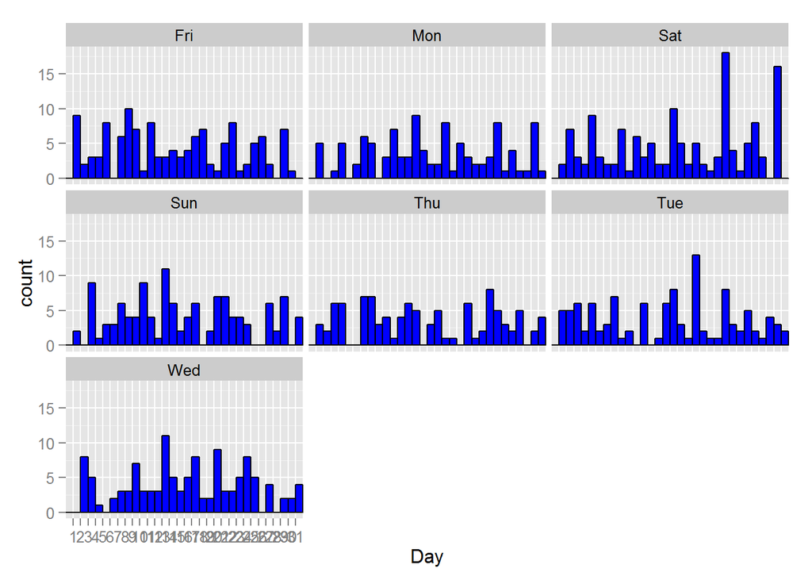

```r
p <- ggplot(fbdata,aes(Day)) +
  geom_histogram(color='black',fill='blue',binwidth=1) +
  scale_x_discrete(limits=c(1:31)) +
  facet_wrap(~Day.of.week,ncol = 3)
p
```

```
## stat_bin: binwidth defaulted to range/30. Use 'binwidth = x' to adjust this.
## stat_bin: binwidth defaulted to range/30. Use 'binwidth = x' to adjust this.
## stat_bin: binwidth defaulted to range/30. Use 'binwidth = x' to adjust this.
## stat_bin: binwidth defaulted to range/30. Use 'binwidth = x' to adjust this.
## stat_bin: binwidth defaulted to range/30. Use 'binwidth = x' to adjust this.
## stat_bin: binwidth defaulted to range/30. Use 'binwidth = x' to adjust this.
## stat_bin: binwidth defaulted to range/30. Use 'binwidth = x' to adjust this.
```

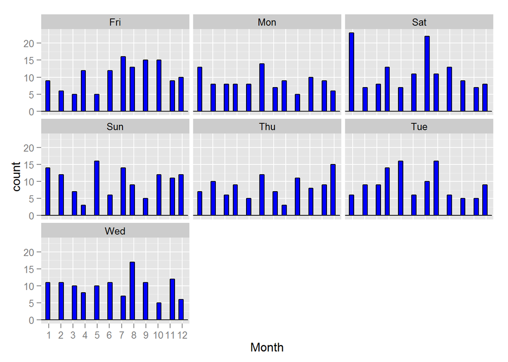

```r
p1 <- ggplot(fbdata,aes(Month)) +
  geom_histogram(color='black',fill='blue') +
  scale_x_discrete(limits=c(1:12)) +
  facet_wrap(~Day.of.week,ncol = 3)
p1
```

```r
ggsave('Histogram_by_month.jpg',p1)
```

```
## stat_bin: binwidth defaulted to range/30. Use 'binwidth = x' to adjust this.
## stat_bin: binwidth defaulted to range/30. Use 'binwidth = x' to adjust this.
## stat_bin: binwidth defaulted to range/30. Use 'binwidth = x' to adjust this.
## stat_bin: binwidth defaulted to range/30. Use 'binwidth = x' to adjust this.
## stat_bin: binwidth defaulted to range/30. Use 'binwidth = x' to adjust this.
## stat_bin: binwidth defaulted to range/30. Use 'binwidth = x' to adjust this.
## stat_bin: binwidth defaulted to range/30. Use 'binwidth = x' to adjust this.
```

```r
ggsave('Histogram_by_day.jpg',p)
str(fbdata)
```

```
## 'data.frame':    824 obs. of  5 variables:
##  $ Title      : Factor w/ 821 levels "Ãskar Ly's Birthday",..: 183 50 502 363 412 353 199 398 610 386 ...
##  $ Year       : chr  "2015" "2015" "2015" "2015" ...
##  $ Month      : num  11 11 11 11 11 11 11 11 11 11 ...
##  $ Day        : num  25 26 26 26 27 28 29 29 29 30 ...
##  $ Day.of.week: Factor w/ 7 levels "Fri","Mon","Sat",..: 7 5 5 5 1 3 4 4 4 2 ...
```

```r
table(fbdata$Day.of.week)
```

```
##
## Fri Mon Sat Sun Thu Tue Wed
## 127 105 139 121 102 111 119
```

```r
#?facet_wrap
```

```r
# How many people share your birthday? Do you know them?
fbdata %>% filter(Day == 21 & Month == 8)
```

```
##                                    Title Year Month Day Day.of.week
## 1 George CaptainObvious Davis's Birthday 2016     8  21         Sun
## 2          Ransford Hyman Jr.'s Birthday 2016     8  21         Sun
## 3                Albert Green's Birthday 2016     8  21         Sun
```

```r
# (Reserve time with them or save money to buy them a gift!)

# Which month contains the most number of birthdays?
fbdata %>% group_by(Month) %>% summarise(n=n()) %>% arrange(desc(n))
```

```
## Source: local data frame [12 x 2]
##
##    Month     n
##    (dbl) (int)
## 1      1    83
## 2      7    83
## 3      8    78
## 4      6    72
## 5      4    67
## 6      5    67
## 7      9    66
## 8     12    66
## 9     10    64
## 10     2    63
## 11    11    62
## 12     3    53
```

```r
# How many birthdays are in each month?
fbdata %>% group_by(Month) %>% summarise(n=n()) %>% arrange(desc(n))
```

```
## Source: local data frame [12 x 2]
##
##    Month     n
##    (dbl) (int)
## 1      1    83
## 2      7    83
## 3      8    78
## 4      6    72
## 5      4    67
## 6      5    67
## 7      9    66
## 8     12    66
## 9     10    64
## 10     2    63
## 11    11    62
## 12     3    53
```

```r
# Which day of the year has the most number of birthdays?

fbdata %>% group_by(Month,Day) %>% summarise(n=n()) %>% arrange(desc(n))
```

```
## Source: local data frame [306 x 3]
## Groups: Month [12]
##
##    Month   Day     n
##    (dbl) (dbl) (int)
## 1      1    30    10
## 2      1    23     6
## 3      1     1     4
## 4      1    10     4
## 5      1    18     4
## 6      1    20     4
## 7      1     4     3
## 8      1    11     3
## 9      1    13     3
## 10     1    16     3
## ..   ...   ...   ...
```

```r
# Do you have at least 365 friends that have birthdays on everyday
# of the year?
unique <- fbdata %>% group_by(Day,Month) %>% count(Day,Month)
dim(unique)
```

```
## [1] 306   3
```